# Actividad 2.8

Lucero Díaz

2026-10-10

```r
library(ISLR2)
library(MASS)
library(class)
library(e1071)
library(car)
library(lmtest)
data("Weekly")
summary(Weekly)
```

```
##       Year           Lag1               Lag2               Lag3
##  Min.   :1990   Min.   :-18.1950   Min.   :-18.1950   Min.   :-18.1950
##  1st Qu.:1995   1st Qu.: -1.1540   1st Qu.: -1.1540   1st Qu.: -1.1580
##  Median :2000   Median :  0.2410   Median :  0.2410   Median :  0.2410
##  Mean   :2000   Mean   :  0.1506   Mean   :  0.1511   Mean   :  0.1472
##  3rd Qu.:2005   3rd Qu.:  1.4050   3rd Qu.:  1.4090   3rd Qu.:  1.4090
##  Max.   :2010   Max.   : 12.0260   Max.   : 12.0260   Max.   : 12.0260
##       Lag4               Lag5              Volume            Today
##  Min.   :-18.1950   Min.   :-18.1950   Min.   :0.08747   Min.   :-18.1950
##  1st Qu.: -1.1580   1st Qu.: -1.1660   1st Qu.:0.33202   1st Qu.: -1.1540
##  Median :  0.2380   Median :  0.2340   Median :1.00268   Median :  0.2410
##  Mean   :  0.1458   Mean   :  0.1399   Mean   :1.57462   Mean   :  0.1499
##  3rd Qu.:  1.4090   3rd Qu.:  1.4050   3rd Qu.:2.05373   3rd Qu.:  1.4050
##  Max.   : 12.0260   Max.   : 12.0260   Max.   :9.32821   Max.   : 12.0260
##  Direction
##  Down:484
##  Up  :605
##
##
##
##
```

### Parte 1.

Divida el conjunto de datos en un conjunto de:

- Entrenamiento (Observaciones desde 1990 hasta 2008)
- Prueba (Observaciones desde 2009 y 2010)

```r
# Entrenamiento: 1990 a 2008
# Prueba: 2009 a 2010
train <- (Weekly$Year < 2009)
Weekly.train <- Weekly[train, ]
Weekly.test  <- Weekly[!train, ]

Direction.test <- Weekly$Direction[!train]
```

## Parte 2.

Formule un modelo de regresión logística con el cual predecir el rendimiento actual del índice bursátil.

```r
# Ajuste del modelo logístico simple con el conjunto de entrenamiento
fit.glm <- glm(Direction ~ Lag2, data = Weekly.train, family = binomial)

# Resumen del modelo
summary(fit.glm)
```

```
##
## Call:
## glm(formula = Direction ~ Lag2, family = binomial, data = Weekly.train)
##
## Coefficients:
##             Estimate Std. Error z value Pr(>|z|)
## (Intercept)  0.20326    0.06428   3.162  0.00157 **
## Lag2         0.05810    0.02870   2.024  0.04298 *
## ---
## Signif. codes:  0 '***' 0.001 '**' 0.01 '*' 0.05 '.' 0.1 ' ' 1
##
## (Dispersion parameter for binomial family taken to be 1)
##
##     Null deviance: 1354.7  on 984  degrees of freedom
## Residual deviance: 1350.5  on 983  degrees of freedom
## AIC: 1354.5
##
## Number of Fisher Scoring iterations: 4
```

## Parte 3.

Escriba el modelo de regresión logística. Tomando en cuenta los resultados obtenidos en el modelo de regresión logística, el modelo se expresa de la siguiente forma:

Ecuación en forma Logit:

$$\text{logit}(\text{Direction}) = 0.20326
+ 0.05810 \cdot \text{Lag}_2$$

Ecuación en forma de Probabilidad:

$$p(\text{Direction}) = \frac{e^{0.20326 +
0.05810 \cdot \text{Lag}_2}}{1 + e^{0.20326 + 0.05810 \cdot
\text{Lag}_2}}$$

## Parte 4.

```r
coef_summary <- summary(fit.glm)$coefficients
beta0 <- coef_summary["(Intercept)", "Estimate"]
beta1 <- coef_summary["Lag2", "Estimate"]
p_value_lag2 <- coef_summary["Lag2", "Pr(>|z|)"]

cat("Beta_0 (Intercepto):", beta0, "\n")
```

```
## Beta_0 (Intercepto): 0.2032574
```

```r
cat("Beta_1 (Lag2):", beta1, "\n")
```

```
## Beta_1 (Lag2): 0.05809527
```

```r
cat("p-value de Lag2:", p_value_lag2, "\n")
```

```
## p-value de Lag2: 0.04297934
```

```r
cat("Odds Ratio (exp(Beta_1)):", exp(beta1), "\n")
```

```
## Odds Ratio (exp(Beta_1)): 1.059816
```

```r
# Probabilidad predicha para Lag2 = 0
prob_lag2_0 <- exp(beta0) / (1 + exp(beta0))
cat("Probabilidad predicha cuando Lag2 = 0:", prob_lag2_0, "\n")
```

```
## Probabilidad predicha cuando Lag2 = 0: 0.5506401
```

- ¿Es estadísticamente significativo el predictor ($\text{Lag}_2$)? ¿Cuál es su p-value?

Como el p-value de $\text{Lag}_2$ es menor a 0.05, se rechaza la hipótesis nula $H_0$, por lo que podemos confirmar que este predictor es estadísticamente significativo.

- ¿Qué indica el valor LaTeX: $\beta_1$?:

Por por cada unidad que se incrementa la variable Lag2, se espera que el logaritmo de odds de la variable Direction se incremente en promedio 0.0581 unidades.

Es decir, por cada unidad que se incrementa la variable $\text{Lag}_2$, los odds de que Direction sea “Up” se incrementan en promedio 1.0598 unidades (lo que representa un incremento del 5.98% en la razón de momios, ya que $e^{0.0581} \approx 1.0598$). Esto corresponde a una probabilidad de que el mercado tenga un valor positivo en el día de hoy (evaluado con $\text{Lag}_2 = 0$) de p = 0.5506 (o 55.06%).

## Parte 5.

Represente gráficamente el modelo, grafique la curva de regresión logarítmica.

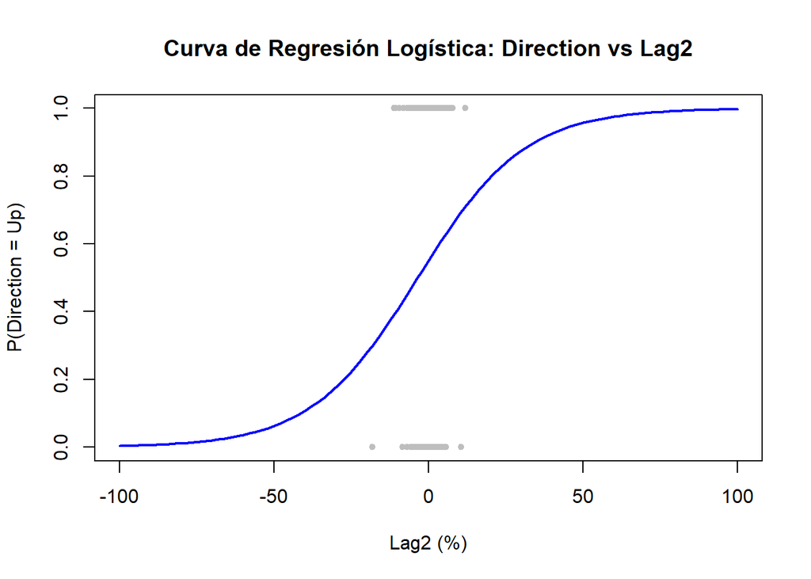

```r
plot(Weekly.train$Lag2, ifelse(Weekly.train$Direction == "Up", 1, 0),
     xlab = "Lag2 (%)", ylab = "P(Direction = Up)",
     main = "Curva de Regresión Logística: Direction vs Lag2",
     col = "gray", pch = 20,
     xlim = c(-100, 100), ylim = c(0, 1))

curve(predict(fit.glm, newdata = data.frame(Lag2 = x), type = "response"),
      from = -100, to = 100, add = TRUE, col = "blue", lwd = 2)
```

## Parte 6.

Evalúe el modelo.

```r
# ANOVA para comparar la devianza nula vs devianza residual
anova(fit.glm, test = "Chisq")
```

```
## Analysis of Deviance Table
##
## Model: binomial, link: logit
##
## Response: Direction
##
## Terms added sequentially (first to last)
##
##
##      Df Deviance Resid. Df Resid. Dev Pr(>Chi)
## NULL                   984     1354.7
## Lag2  1   4.1666       983     1350.5  0.04123 *
## ---
## Signif. codes:  0 '***' 0.001 '**' 0.01 '*' 0.05 '.' 0.1 ' ' 1
```

```r
# Predicción de probabilidades en datos de prueba
glm.probs <- predict(fit.glm, Weekly.test, type = "response")

# Clasificación según el umbral estándar p = 0.5
glm.pred <- rep("Down", nrow(Weekly.test))
glm.pred[glm.probs > 0.5] <- "Up"

# Matriz de confusión (Tabla de contingencia)
conf_matrix <- table(glm.pred, Direction.test)
print(conf_matrix)
```

```
##         Direction.test
## glm.pred Down Up
##     Down    9  5
##     Up     34 56
```

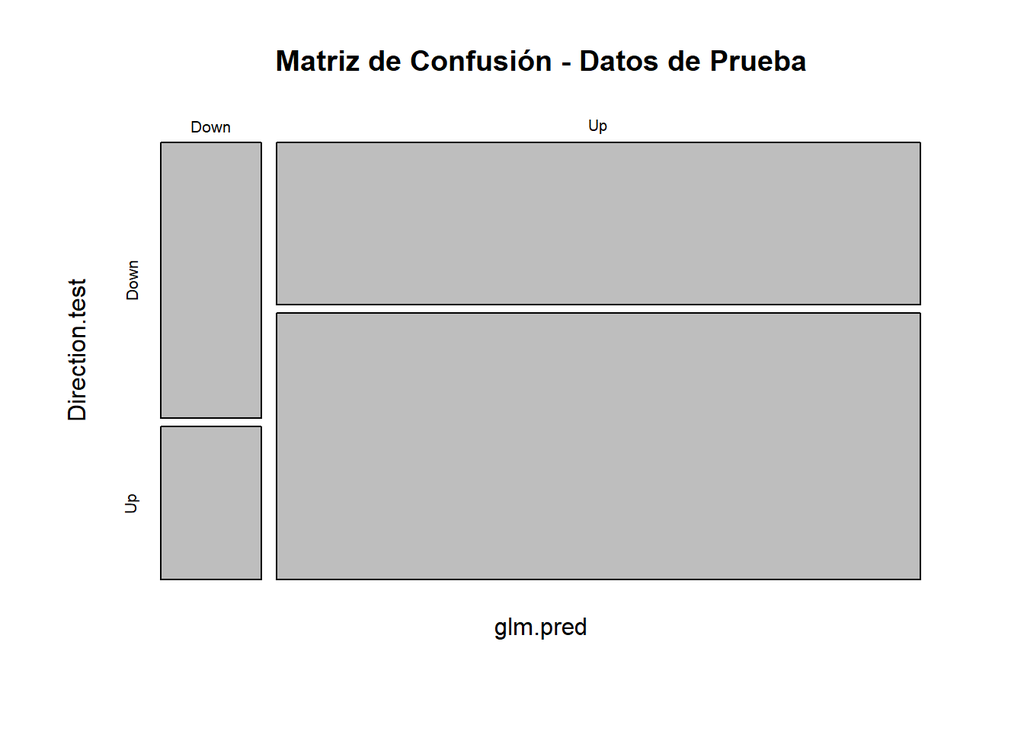

```r
# Diagrama de mosaico
mosaicplot(conf_matrix, main = "Matriz de Confusión - Datos de Prueba")
```

```r
# Cálculo de métricas
accuracy    <- mean(glm.pred == Direction.test) * 100
error_rate  <- 100 - accuracy
sensitivity <- (conf_matrix["Up", "Up"] / sum(Direction.test == "Up")) * 100
specificity <- (conf_matrix["Down", "Down"] / sum(Direction.test == "Down")) * 100

cat(sprintf("\nPorcentaje de predicciones correctas (Accuracy): %.2f%%\n", accuracy))
```

```
##
## Porcentaje de predicciones correctas (Accuracy): 62.50%
```

```r
cat(sprintf("\nTasa de error: %.2f%%\n", error_rate))
```

```
##
## Tasa de error: 37.50%
```

```r
cat(sprintf("\nSensibilidad: Para aquellas semanas con un valor de mercado al alza, de todas las observaciones el modelo clasifica correctamente el %.2f%%\n", sensitivity))
```

```
##
## Sensibilidad: Para aquellas semanas con un valor de mercado al alza, de todas las observaciones el modelo clasifica correctamente el 91.80%
```

```r
cat(sprintf("\nEspecificidad: Para las semanas con un valor de mercado a la baja, de todas las observaciones el modelo acierta en un %.2f%%\n", specificity))
```

```
##
## Especificidad: Para las semanas con un valor de mercado a la baja, de todas las observaciones el modelo acierta en un 20.93%
```

Aunque la precisión total es del $62.5\%$, el modelo tiene una fuerte tendencia a predecir “Up” (alta sensibilidad del $91.8\%$), pero falla considerablemente al detectar semanas a la baja “Down” (baja especificidad del $20.9\%$).

## Parte 7.

```r
# A. Independencia (Prueba de Durbin-Watson sobre residuos)
dwtest(fit.glm)
```

```
##
##  Durbin-Watson test
##
## data:  fit.glm
## DW = 2.154, p-value = 0.9923
## alternative hypothesis: true autocorrelation is greater than 0
```

```r
# C. Linealidad entre el predictor y el logit
# Prueba de Box-Tidwell

# Crear una versión desplazada de Lag2 que sea solo positiva
Lag2_positiva <- Weekly.train$Lag2 - min(Weekly.train$Lag2) + 1

# Ejecutar Box-Tidwell con la variable positiva
boxTidwell(logit(Direction == "Up") ~ Lag2_positiva, data = Weekly.train)
```

```
##  MLE of lambda Score Statistic (t) Pr(>|t|)
##         4.0798               0.632   0.5275
##
## iterations =  19
```

## Declaratoria de uso de IA durante el desarrollo del trabajo

Se utilizó IA:

1. Herramienta: Gemini
2. Uso realizado: Ayuda en el código a lo largo de la tarea, así como también en el formato del documento y preguntas puntuales para interpretación.
3. Secciones donde se utilizó: En todas las secciones hubo apoyo al momento de escribir el código, así como también en la sección 3 ayudó a escribir las fórmulas que describen el modelo en markdown.
4. Validación realizada por los estudiantes: Se verificó, corrió y depuró todo el script de R, así como también analizaron todos los resultados arrojados para validar que todo estuviera correcto y en orden.
5. Confirmo de que se revisó, verificó y que se asume la responsabilidad del contenido final entregado.